# GGPlot2 for PM566

Paul M

3/26/2020

# What is this lecture?

[figure not shown]

This lecture provides an introduction to ggplot2, an R package that provides vastly better graphics options than R’s default plots, histrograms, etc.

This section is based on chapter 3 of “R for Data Science”, by Grolemund and Wickham: https://r4ds.had.co.nz/

### Background

ggplot2 is part of the Tidyverse. The tidyverse is…“an opinionated collection of R packages designed for data science. All packages share an underlying design philosophy, grammar, and data structures.” (https://www.tidyverse.org/)

You will get to know it better later in the course.

```r
#install.packages("tidyverse")
library(tidyverse)
```

### Data frames

```r
index = c(1, 2, 3)
animal = c("cat", "dog", "rabbit")
owned = c(TRUE, FALSE, FALSE)
df = data.frame(index, animal, owned)       # df is a data frame
print(df)
```

```
##   index animal owned
## 1     1    cat  TRUE
## 2     2    dog FALSE
## 3     3 rabbit FALSE
```

The top line of the table is called the header and contains the variable names.

Here is a data frame that is part of ggplot2:

```r
mpg
```

| manufacturer | model | displ | year | cyl | trans | drv | cty | hwy | fl | class |
| --- | --- | --- | --- | --- | --- | --- | --- | --- | --- | --- |
| audi | a4 | 1.8 | 1999 | 4 | auto(l5) | f | 18 | 29 | p | compact |
| audi | a4 | 1.8 | 1999 | 4 | manual(m5) | f | 21 | 29 | p | compact |
| audi | a4 | 2.0 | 2008 | 4 | manual(m6) | f | 20 | 31 | p | compact |
| audi | a4 | 2.0 | 2008 | 4 | auto(av) | f | 21 | 30 | p | compact |
| audi | a4 | 2.8 | 1999 | 6 | auto(l5) | f | 16 | 26 | p | compact |
| audi | a4 | 2.8 | 1999 | 6 | manual(m5) | f | 18 | 26 | p | compact |
| audi | a4 | 3.1 | 2008 | 6 | auto(av) | f | 18 | 27 | p | compact |
| audi | a4 quattro | 1.8 | 1999 | 4 | manual(m5) | 4 | 18 | 26 | p | compact |
| audi | a4 quattro | 1.8 | 1999 | 4 | auto(l5) | 4 | 16 | 25 | p | compact |
| audi | a4 quattro | 2.0 | 2008 | 4 | manual(m6) | 4 | 20 | 28 | p | compact |

[output cut: 224 more lines]

```r
head(mpg)
```

| manufacturer | model | displ | year | cyl | trans | drv | cty | hwy | fl | class |
| --- | --- | --- | --- | --- | --- | --- | --- | --- | --- | --- |
| audi | a4 | 1.8 | 1999 | 4 | auto(l5) | f | 18 | 29 | p | compact |
| audi | a4 | 1.8 | 1999 | 4 | manual(m5) | f | 21 | 29 | p | compact |
| audi | a4 | 2.0 | 2008 | 4 | manual(m6) | f | 20 | 31 | p | compact |
| audi | a4 | 2.0 | 2008 | 4 | auto(av) | f | 21 | 30 | p | compact |
| audi | a4 | 2.8 | 1999 | 6 | auto(l5) | f | 16 | 26 | p | compact |
| audi | a4 | 2.8 | 1999 | 6 | manual(m5) | f | 18 | 26 | p | compact |

The variables we will focus on for this example are

- displ, a car’s engine size, in litres.
- hwy, a car’s fuel efficiency on the highway, in miles per gallon (mpg).

### Basic plot 1

Here’s how to create a basic plot in ggplot2

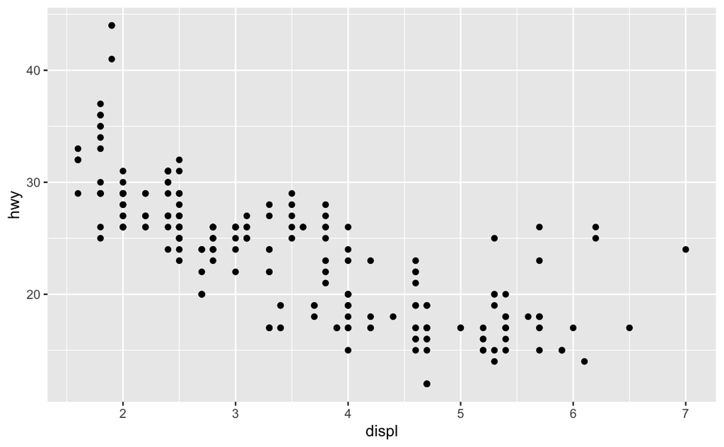

```r
ggplot(data = mpg) +
  geom_point(mapping = aes(x = displ, y = hwy))
```

As expected, we see that cars with big engines use more fuel.

ggplot2 begins a plot with the function ggplot(), which creates a coordinate system that you can add layers to. The first argument of ggplot() is the dataset to use in the graph.

You complete the graph by adding one or more layers to ggplot().

### Basic plot 2

geom_point() adds a layer of points to your plot, to create a scatterplot.

ggplot2 comes with many geom functions that each add a different type of layer to a plot.

Each geom function in ggplot2 takes a mapping argument. This defines how variables in your dataset are mapped to visual properties. The mapping argument is always paired with aes(), and the x and y arguments of aes() specify which variables to map to the x and y axes. ggplot2 looks for the mapped variables in the data argument, in this case, mpg.

One common problem when creating ggplot2 graphics is to put the + in the wrong place: it has to come at the end of the line, not the start.

### Determining point size using a variable

You can map point size to a variable as well:

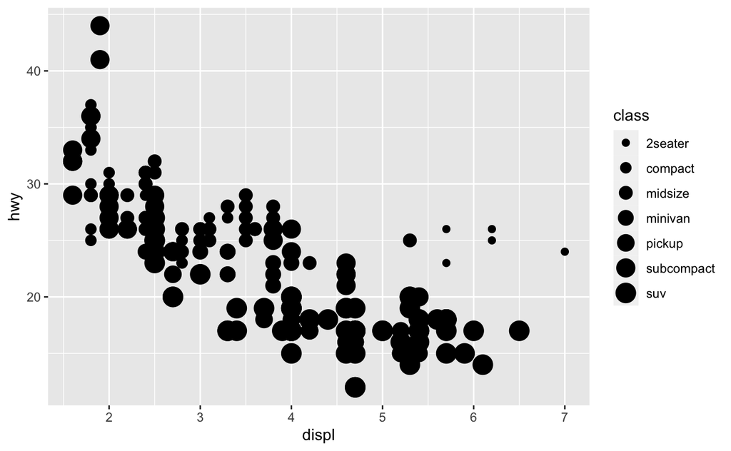

```r
ggplot(data = mpg) +
  geom_point(mapping = aes(x = displ, y = hwy, size = class))
```

### Controlling point transparency using the “alpha” aesthetic

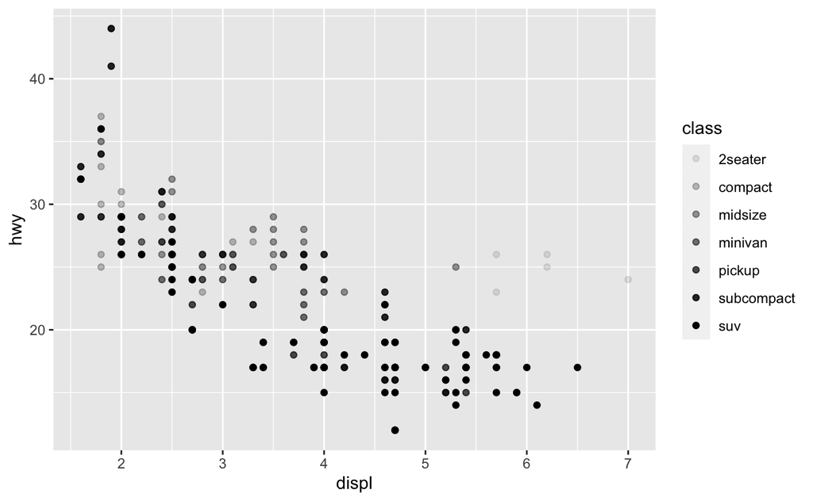

```r
ggplot(data = mpg) +
  geom_point(mapping = aes(x = displ, y = hwy, alpha = class))
```

### Controlling point shape:

```
## Warning: The shape palette can deal with a maximum of 6 discrete values because
## more than 6 becomes difficult to discriminate; you have 7. Consider
## specifying shapes manually if you must have them.
```

```
## Warning: Removed 62 rows containing missing values (geom_point).
```

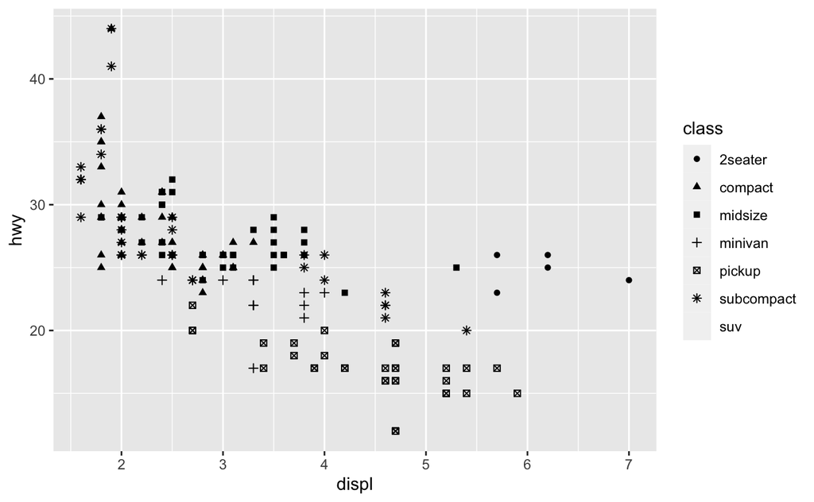

```r
ggplot(data = mpg) +
  geom_point(mapping = aes(x = displ, y = hwy, shape = class))
```

Note that, by default, ggplot uses up to 6 shapes. If there are more, some of your data is not plotted!! (At least it warns you.)

### Manual control of aesthetics

To control aesthetics manually, set the aesthetic by name as an argument of your geom function; i.e. it goes outside of aes().

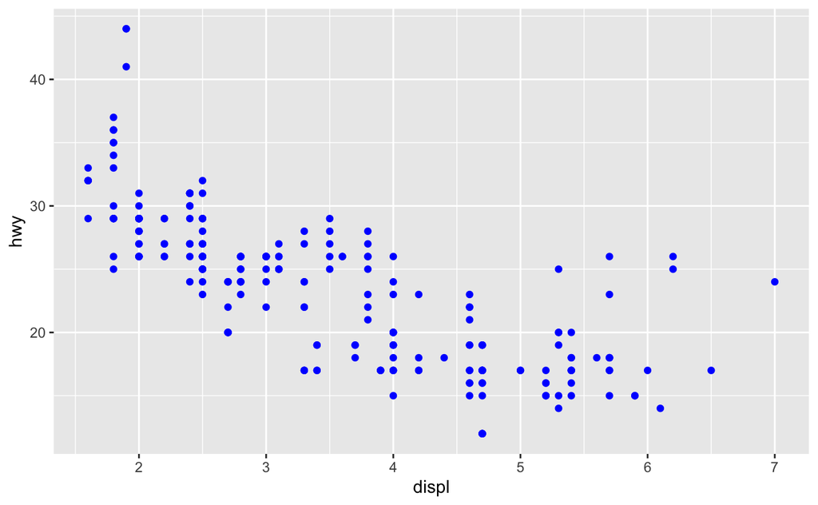

```r
ggplot(data = mpg) +
  geom_point(mapping = aes(x = displ, y = hwy), color = "blue")
```

### Summary of aesthetics

#The various aestheticss…

| code | description |
| --- | --- |
| x | position on x-axis |
| y | position on y-axis |
| shape | shape |
| color | color of element borders |
| fill | color inside of elements |
| size | size |
| alpha | transparency |
| linetype | type of line |

### Facets 1

Facets are particularly useful for categorical variables…

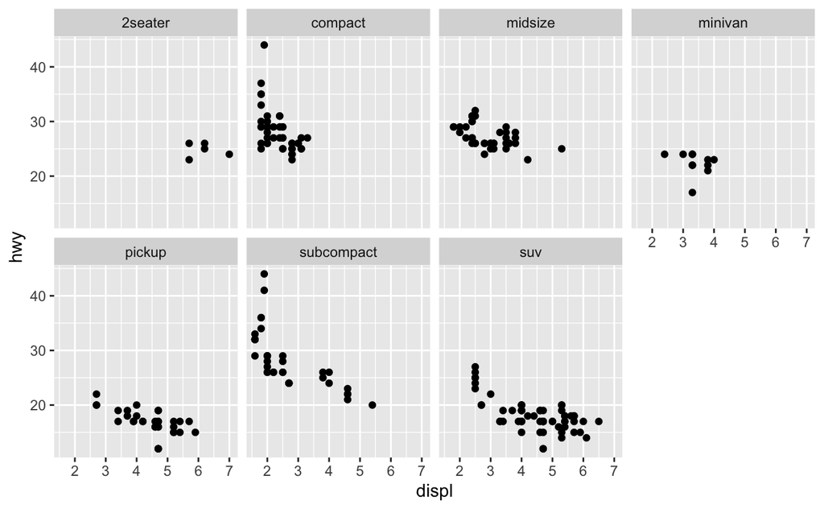

```r
ggplot(data = mpg) +
  geom_point(mapping = aes(x = displ, y = hwy)) +
  facet_wrap(~ class, nrow = 2)
```

### Facets 2

Or you can facet on two variables…

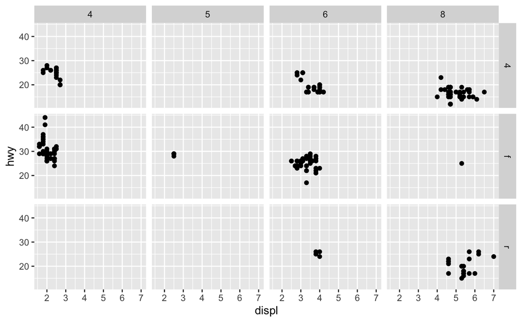

```r
ggplot(data = mpg) +
  geom_point(mapping = aes(x = displ, y = hwy)) +
  facet_grid(drv ~ cyl)
```

### Geometric objects 1

Geometric objests are used to control the type of plot you draw. So far we have used scatterplots (via ‘geom_point’). But now let’s try plotting a smoothed line fitted to the data (and note how we do side-by-side plots)

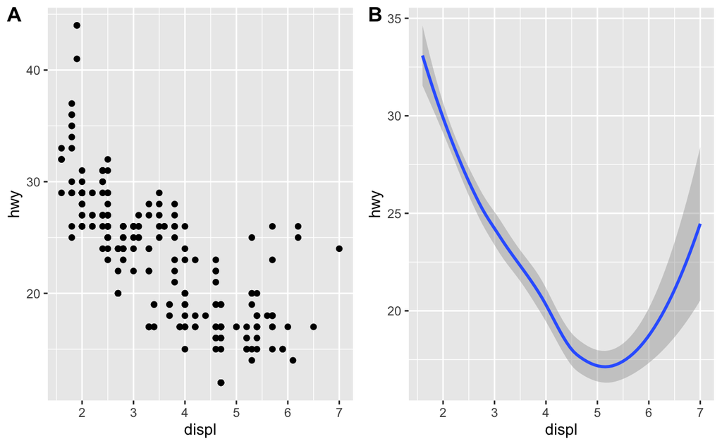

```r
library(cowplot)
#library(gridExtra)
scatterplot <- ggplot(data = mpg) + geom_point(mapping = aes(x = displ, y = hwy))
lineplot <- ggplot(data = mpg) + geom_smooth(mapping = aes(x = displ, y = hwy))
plot_grid(scatterplot, lineplot, labels = "AUTO")
```

```r
#grid.arrange(scatterplot, lineplot, ncol = 2)
```

### Geometric objects 2

Note that not every aesthetic works with every geom function. But now there are some new ones we can use.

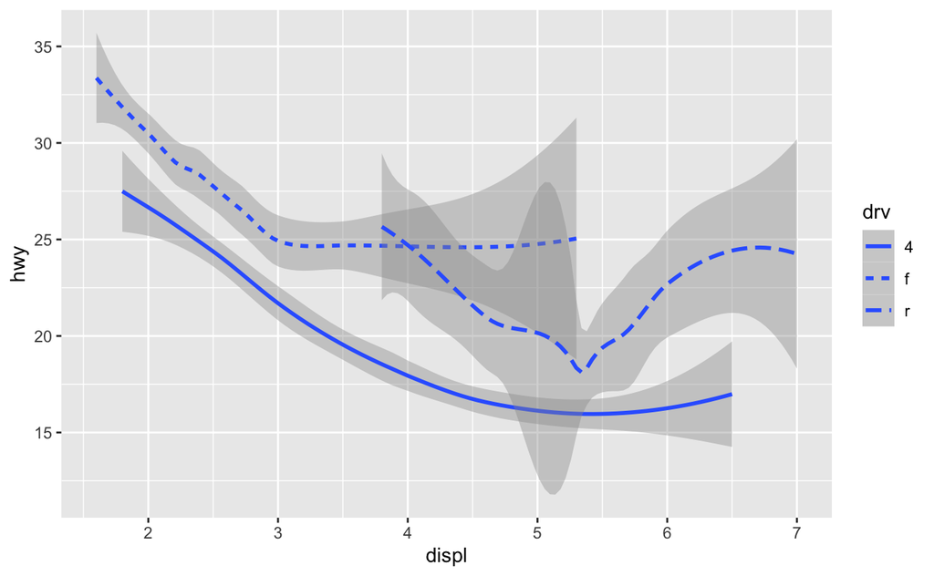

```r
ggplot(data = mpg) +
  geom_smooth(mapping = aes(x = displ, y = hwy, linetype = drv))
```

Here we make the line type depend on the cars drivetrain.

### Geoms - reference

ggplot2 provides over 40 geoms, and extension packages provide even more (see https://ggplot2.tidyverse.org/reference/ for a sampling).

The best way to get a comprehensive overview is the ggplot2 cheatsheet, which you can find at https://rstudio.com/wp-content/uploads/2015/03/ggplot2-cheatsheet.pdf

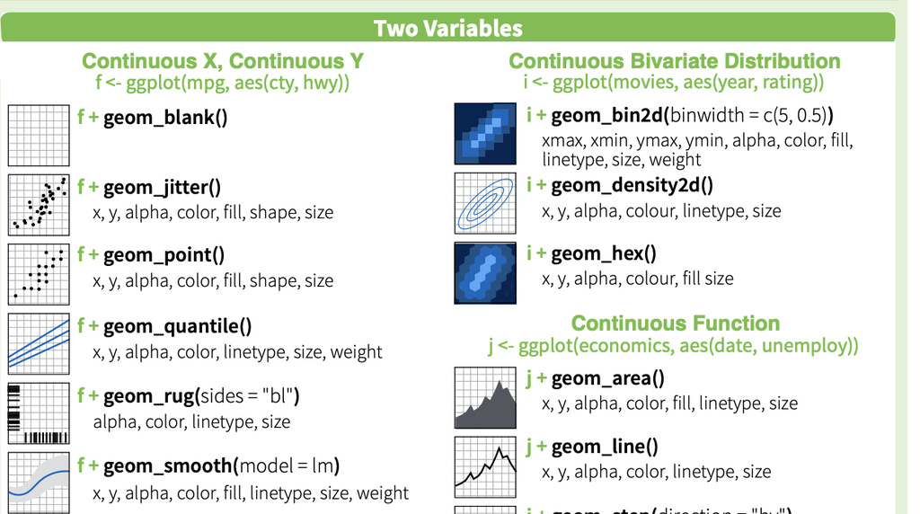

### File under useless but cool

ggpattern - library for adding pattern fills to histograms. e.g.,

[figure not shown]

```r
# install.packages("remotes")
# remotes::install_github("coolbutuseless/ggpattern")
suppressPackageStartupMessages({
library(ggpattern)
})
df <- data.frame(level = c("a", "b", "c", 'd'), outcome = c(2.3, 1.9, 3.2, 1))

ggplot(df) +
  geom_col_pattern(
    aes(level, outcome, pattern_fill = level),
    pattern = 'stripe',
    fill    = 'white',
    colour  = 'black'
  ) +
  theme_bw(18) +
  theme(legend.position = 'none') +
  labs(
    title    = "ggpattern::geom_pattern_col()",
    subtitle = "pattern = 'stripe'"
  ) +
  coord_fixed(ratio = 1/2)
```

### Reminder - the ggplot2 cheatsheet

https://rstudio.com/wp-content/uploads/2015/03/ggplot2-cheatsheet.pdf

Rstudio has a variety of great Cheatsheets.

### The remaining slides are “notes to self”

Figure placement in Xaringen…

[figure not shown]

[figure not shown]

# How to use baxckground images?

This doesn’t work when knitted to html…

This lecture provides an introduction to ggplot2, an R package that provides vastly better graphics options than R’s default plots, histrograms, etc.

This section is based on chapter 3 of “R for Data Science”, by Grolemund and Wickham: https://r4ds.had.co.nz/

This is how to introduce slide elements incrementally in Xaringen (i.e. use the –)

The holy passion of Friendship is of so sweet and steady and loyal and enduring a nature that it will last through a whole lifetime…

*if not asked to lend money*.

— Mark Twain

### Other Resources:

“Mastering Software Development in R” - Roger Peng which can be found at https://bookdown.org/rdpeng/RProgDA/basic-plotting-with-ggplot2.html